# The life changing magic of tidying your R code

Christine Stawitz

ECS Federal in support of NOAA Fisheries S & T

April 12, 2019

# Background

## NOAA Fisheries National Modeling Team

Mission: to develop, test, document, and provide national analytical tools that facilitate accuracy, efficiency, and utility of stock assessment methods

## Defining standards for modeling tools

- Documentation
- Testing
- Examples and tutorials
- Standard inputs and outputs
- Reproducible coding standards
- Scientific rigor (published references)

## Best investments for researchers

- Your next user will probably be you, in a few months
- Reduces errors
- Makes paper writing/review process less painful
- Enables easy re-use of functions
- Makes running on a new dataset simpler
- Enables easier sharing later

## A personal anecdote

- Chapter 1: not written well
- Errors were found
- Re-written in python, and `TMB` (soon)

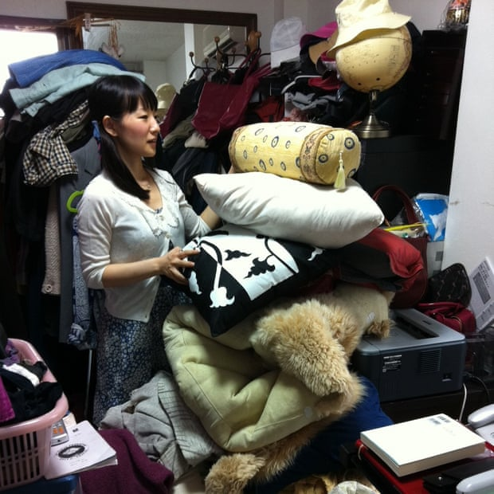

## A personal anecdote

- Chapter 2: Used functions and error messages and kept code/outputs organized
- Rejected twice

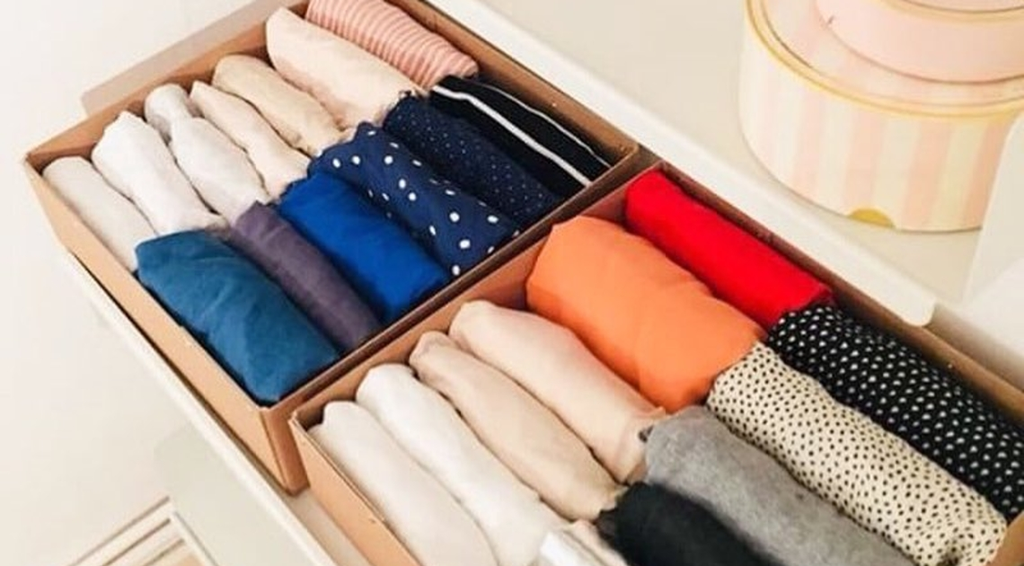

## “Good enough” practices

- [Good enough practices in scientific computing](https://journals.plos.org/ploscompbiol/article/file?id=10.1371/journal.pcbi.1005510&type=printable) (2017) PLos One Computational Bio; Wilson, Bryan, Cranston, Kitzes, Nederbragt & Teal

## Topics

- Reproducible architecture
- Basic documentation
- Errors

# Reproducible architecture

## Overview

- Logically organize project directories
- Explicitly define dependencies
- Use functional programming
- Ruthlessly avoid duplication
- Meaningful consistent naming

## Project directory organization

- Use different directories to separate inputs, outputs, code, and docs

  ```
  |-- requirements.txt
  |-- data
  | |-- raw_foofy_data.csv
  |-- doc
  | |-- notebook.md
  | |-- manuscript.md
  | |-- changelog.txt
  |-- figs
  | |-- foofy_scatterplot.png
  |-- src
  | |-- make_plots.R
  ```

- ideally using git

## Relative rather than hardcoded paths to files

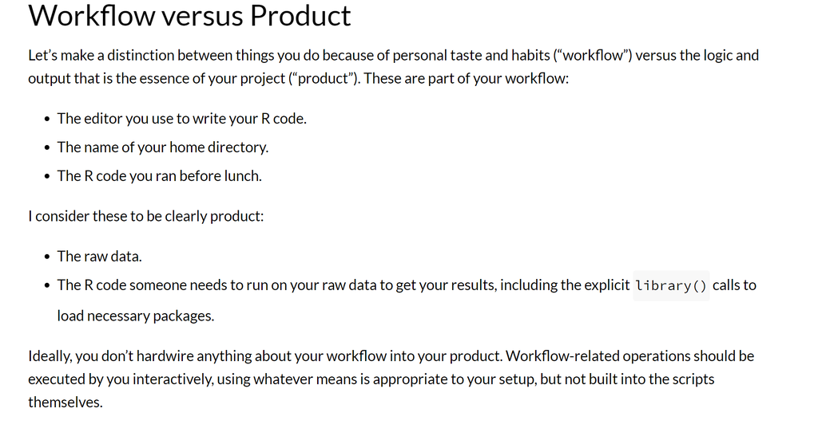

- From [this](https://www.tidyverse.org/articles/2017/12/workflow-vs-script/)

## Example from jennybc

```r
#Bad
library(ggplot2)
setwd("/Users/jenny/cuddly_broccoli/verbose_funicular/foofy/data")
df <- read.delim("raw_foofy_data.csv")
p <- ggplot(df, aes(x, y)) + geom_point()
ggsave("../figs/foofy_scatterplot.png")

#Better
library(ggplot2)
library(here)

df <- read.delim(here("data", "raw_foofy_data.csv"))
p <- ggplot(df, aes(x, y)) + geom_point()
ggsave(here("figs", "foofy_scatterplot.png"))
```

## Creating R Projects

- `File -> New Project`
- Saves the state of your workspace
- Keeps working directory consistent

## Creating R packages

- Cons:
  - Requires dependencies (Rtools, devtools)
  - Sensitive to directory changes and structure
- Pros:
  - Shortcuts to access/modify package components and git (usethis package)
  - Enforces use of functions & sourcing
  - Easier to convert to a shareable package

## Notebooks

- `File -> New File -> R Notebook`
- Organize text and code together, without re-knitting
- [Example](https://blog.rstudio.com/2016/10/05/r-notebooks/)
- Jupyter: use with `conda` to manage environments and share code easily

## Requirements

- Requirements for program to work
- Tests to ensure program has been installed correctly
- Simplifies returning to and sharing code
- In `DESCRIPTION` if you are making a package

## Changelog

- Could be as simple as `changelog.txt` file
- Easy to add in Notebook
- Using git simplifies this

## Functions

- in `src` or `R` directory
- No more than 60 lines long
- Fewer than 6 arguments
- No globals or `attach()`

## Avoiding duplication

- Make lists/vectors instead of multiple objects
- Use iteration (loops) or mapping (`lapply`, `purrr`) wherever possible
- Never [copy and paste](https://en.wikipedia.org/wiki/Copy_and_paste_programming)

## Example from Advanced R

```r
# Generate a sample dataset
set.seed(1014)
df <- data.frame(replicate(6, sample(c(1:10, -99), 6, rep = TRUE)))
names(df) <- letters[1:6]
df
```

```
##    a  b c   d   e f
## 1  1  6 1   5 -99 1
## 2 10  4 4 -99   9 3
## 3  7  9 5   4   1 4
## 4  2  9 3   8   6 8
## 5  1 10 5   9   8 6
## 6  6  2 1   3   8 5
```

```r
#BAD
df$a[df$a == -99] <- NA
df$b[df$b == -99] <- NA
df$c[df$c == -99] <- NA
df$d[df$d == -99] <- NA
df$e[df$e == -99] <- NA
df$f[df$f == -99] <- NA
```

## Better solutions

- Use a function, `lapply`, or `purrr`

```r
fix_missing <- function(x) {
  x[x == -99] <- NA
  x
}

df[] <- lapply(df, fix_missing)

purrr::map_df(df, fix_missing)
```

## Multiple functions

```r
x <- c(1:10, NA)
funs <- list(
  sum = sum,
  mean = mean,
  median = median
)
lapply(funs, function(f) f(x))

lapply(funs, function(f) f(x, na.rm = TRUE))
```

- More [here](http://adv-r.had.co.nz/Functional-programming.html)

## Meaningful naming and style

- Be consistent
- Human and machine readable
- Don’t use names that mean something (`F`,`sum`)
- Extra credit: [style guide](http://adv-r.had.co.nz/Style.html)
- Help: `lintr` and `styler` packages

# Basic documentation

## Simple comments above every function

- Include above every function a:
  - description
  - detail about each argument
  - detail about the return value
  - examples (extra)

## Documentation example

```r
#' Function that loops through and runs scenarios for each of the life histories in the list
#' @param life.histories - list containing life history parameters for each species
#' @param equils - list of equilibrium values for each stock, Fmsy, Bmsy, Bmax
#' @param nyears - number of years to run the simulation for
#' @param nsims - number of simulations
#' @param f.scen - which of the four fishing scenarios to use; 0 =none, 1=low, 2=med, 3=hi.
#' @return out.stats - a list of the scenarios output, each list item is one stock's output
```

# Errors

## Overview

- Stop
- Debugging
- Unit testing
- Integrated testing

## Error messages

- Use `stop()` to give intelligible feedback
- Check inputs
- Avoid silent failures

```r
  #Check all lifehistory parameters are included
  if(is.null(lh$M)){
    stop("M is missing")
  }
```

## Debugging

- `debugonce(<functionname>)` allows you to step through code
- Functional programming supports easier debugging

## Unit testing

- With `testthat()`

```r
context("String length")
library(stringr)

test_that("str_length is number of characters", {
  expect_equal(str_length("a"), 1)
  expect_equal(str_length("ab"), 2)
  expect_equal(str_length("abc"), 3)
})

test_that("str_length of factor is length of level", {
  expect_equal(str_length(factor("a")), 1)
  expect_equal(str_length(factor("ab")), 2)
  expect_equal(str_length(factor("abc")), 3)
})

test_that("str_length of missing is missing", {
  expect_equal(str_length(NA), NA_integer_)
  expect_equal(str_length(c(NA, 1)), c(NA, 1))
  expect_equal(str_length("NA"), 2)
})
```

## Integrated testing

- Equilibrium diagnostics
- Running with simulated data/fixed inputs
- Example files you can run to test with

## Automation and feedback

- Automate tests with TravisCI
- [Code review on Github](https://github.com/features/code-review/)

## From the Carpentries

- Program defensively, i.e., assume that errors are going to arise, and write code to detect them when they do.
- Write tests before writing code in order to help determine exactly what that code is supposed to do. Know what code is supposed to do before trying to debug it.
- Make it fail every time.
- Make it fail fast.
- Change one thing at a time, and for a reason.
- Keep track of what you’ve done.
- Be humble

# Resources

## Used to build this talk

- [Advanced R](http://adv-r.had.co.nz/)
- [Workflow/paths](https://www.tidyverse.org/articles/2017/12/workflow-vs-script/)
- [Software carpentry](https://software-carpentry.org/)

## If you want to go further

- [Git with R](https://happygitwithr.com/)
- [R packages](http://r-pkgs.had.co.nz/)
- [R notebooks](https://bookdown.org/yihui/rmarkdown/notebook.html)
- [Jupyter for R with conda](https://anaconda.org/chdoig/jupyter-and-conda-for-r/notebook)
- [purrr](https://purrr.tidyverse.org/)
- [Carpentries training](http://swcarpentry.github.io/r-novice-gapminder/reference)